# Bird detection simulator v2: landscape, world and example species

This document shows (1) the standardised landscape, (2) how the simulated world is created, (3) three example species in detail and (4) a demo of the simulator, (5) Comparison of beta prameters estimated using HMSC model fitted to simulated data.

# 1. Setup

50x50 km grid around Jyväskylä with cell size of 200x200 m. Total number of cells = 62,500.

```r
for (f in sort(list.files(params$sim_dir, pattern = "^simv2_0[0-2].*\\.R$", full.names = TRUE))) source(f)

if (!file.exists(params$covariate_file))
  stop("Cannot find the grid CSV '", params$covariate_file, "'.\n",
       "While knitting, R looks relative to the Rmd's folder: ", getwd(), "\n",
       "Use a full path in the header (covariate_file).")

cfg   <- sim_config(seed = params$world_seed, covariate_file = params$covariate_file)
world <- sim_init(cfg)
sp    <- world$species          # the species table (truth)
ok    <- !world$land$water      # TRUE = land cell that can be sampled
cat("Grid:", cfg$nrow, "x", cfg$ncol, "cells; sampled (non-water) cells:", sum(ok), "\n")
```

```
## Grid: 250 x 250 cells; sampled (non-water) cells: 49659
```

# 2. The standardised landscape

All the covariate and cost_surface information for each cell can be found in “grid_200m_all_z.csv”

Forest cover in the cell, edge density and forest cover in the 1 km buffer are z-scored over the non-water cells (mean 0, SD 1). Grey cells are water: they are excluded and never sampled. North is up, west is left. Values are clipped at +/-3 for the colours.

```r
# Colour bar drawn in its own narrow panel next to a map
colour_bar <- function(zlim, col, at = NULL, labels = TRUE) {
  par(mar = c(4, 0.3, 3, 2.5))
  z <- seq(zlim[1], zlim[2], length.out = length(col))
  image(x = 0:1, y = z, z = matrix(z, nrow = 1), col = col, axes = FALSE, xlab = "", ylab = "")
  axis(4, at = at, labels = labels, las = 1)
  box()
}
```

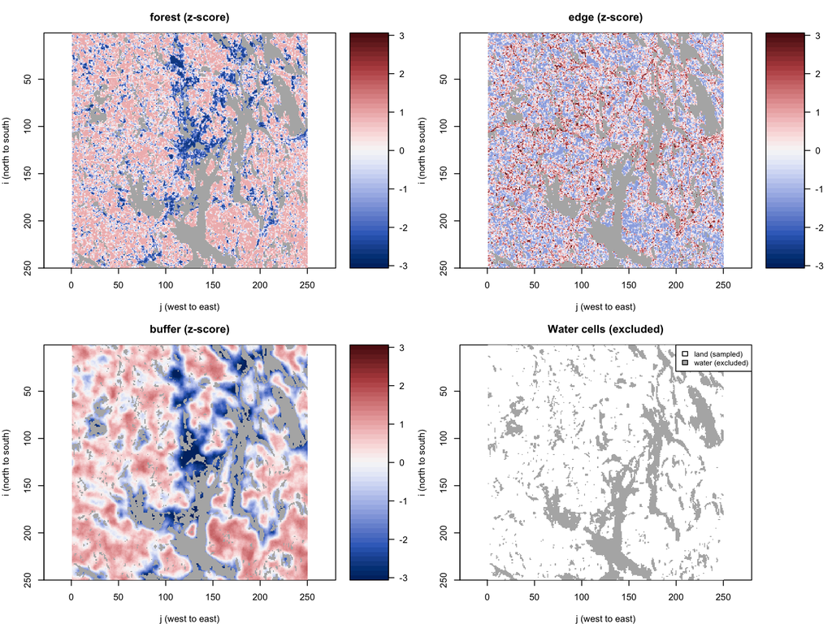

```r
pal  <- hcl.colors(50, "Blue-Red 3")
zlim <- c(-3, 3)
water_ov <- ifelse(world$land$water, 1, NA)

layout(matrix(c(1, 2, 3, 4,
                5, 6, 7, 0), nrow = 2, byrow = TRUE), widths = c(10, 2, 10, 2))
for (nm in cfg$cov_names) {
  par(mar = c(4, 4, 3, 1))
  m <- pmin(pmax(world$land$x[, , nm], -3), 3)
  m[!ok] <- NA
  sim_image(m, main = paste(nm, "(z-score)"), col = pal, zlim = zlim)
  image(seq_len(ncol(m)), seq_len(nrow(m)), t(water_ov), col = "grey70", add = TRUE)
  colour_bar(zlim, pal)
}
par(mar = c(4, 4, 3, 1))
sim_image(matrix(as.integer(world$land$water), nrow(ok)), main = "Water cells (excluded)",
          col = c("white", "grey70"))
legend("topright", fill = c("white", "grey70"), legend = c("land (sampled)", "water (excluded)"),
       bg = "white", cex = 0.8)
```

```r
layout(1)
```

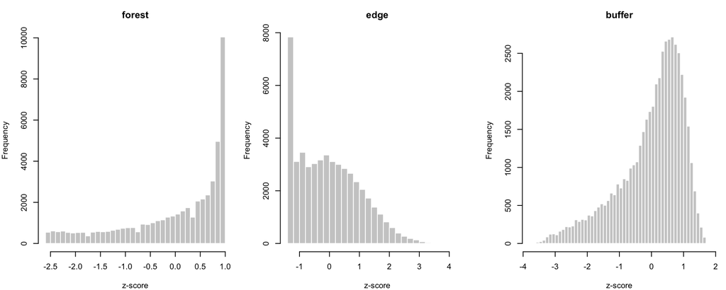

```r
par(mfrow = c(1, 3), mar = c(4, 4, 3, 1))
for (nm in cfg$cov_names)
  hist(world$land$x[, , nm][ok], breaks = 40, main = nm, xlab = "z-score",
       col = "grey80", border = "white")
```

The covariates are skewed and correlated, which makes their effects partly confounded:

```r
knitr::kable(round(cor(world$land$X[as.vector(ok), ]), 2), caption = "Correlation between covariates")
```

Correlation between covariates

|  | forest | edge | buffer |
| --- | --- | --- | --- |
| forest | 1.00 | -0.51 | 0.54 |
| edge | -0.51 | 1.00 | -0.24 |
| buffer | 0.54 | -0.24 | 1.00 |

## Grid cost surface

Figure from the grid pipeline (`grid_cost_surface_v2.png`), shown for context.

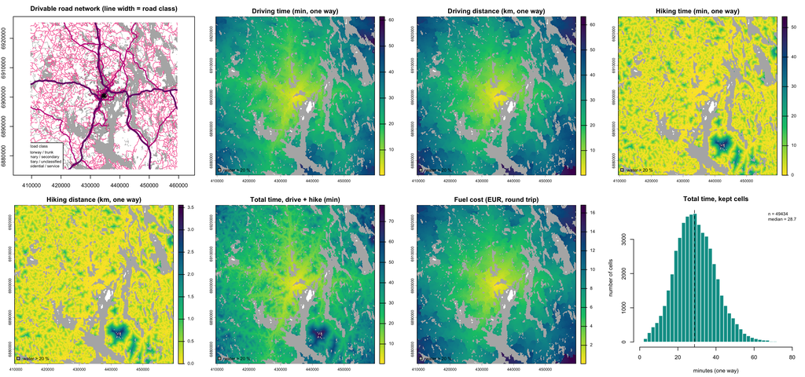

```r
if (file.exists(params$cost_surface_png)) {
  knitr::include_graphics(params$cost_surface_png)
} else {
  cat("Image not found:", params$cost_surface_png, "\nSet cost_surface_png in the header.\n")
}
```

# 3. How the world is created

## 3.1. The community: strategy, prevalence profile and confusable species

Every species can also appear as a visitor in cells it does not occupy (`p_visit`).

### 3.1a. Phenology by strategy

Each curve is one species’ acoustic activity (0 outside its onset and cessation, 1 at the peak), coloured by strategy. Visitor-only species (if any) are dashed. Dotted lines mark the detection season.

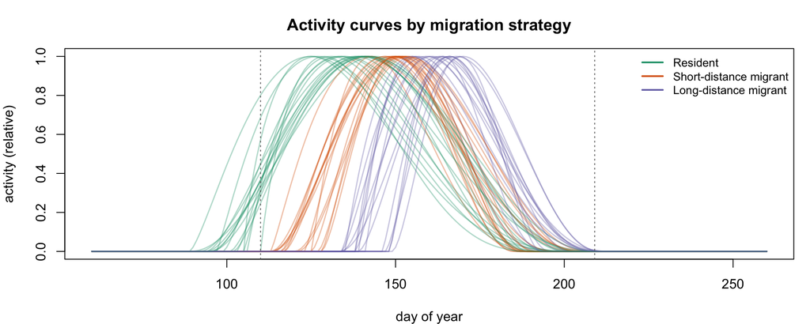

```r
doys   <- 60:260
curves <- sim_activity_curves(sp, doys)
strats  <- c("resident", "short", "long")
labels  <- c(resident = "Resident", short = "Short-distance migrant", long = "Long-distance migrant")
col_occ <- c(resident = "#1b9e77", short = "#d95f02", long = "#7570b3")

par(mfrow = c(1, 1), mar = c(4, 4, 3, 1))
plot(NA, xlim = range(doys), ylim = c(0, 1), xlab = "day of year",
     ylab = "activity (relative)", main = "Activity curves by migration strategy")
for (k in seq_len(nrow(sp))) {
  vo <- sp$visitor_only[k]
  lines(doys, curves[k, ], col = adjustcolor(col_occ[sp$strategy[k]], alpha.f = 0.35),
        lty = if (vo) 2 else 1, lwd = if (vo) 2.5 else 1.5)
}
abline(v = c(cfg$doy_min, cfg$doy_max), lty = 3, col = "grey40")
has_vo <- any(sp$visitor_only)
legend("topright", bty = "n", cex = 0.85,
       legend = c(labels[strats], if (has_vo) "visitor-only (dashed)"),
       col = c(col_occ[strats], if (has_vo) "grey30"),
       lty = c(1, 1, 1, if (has_vo) 2), lwd = 2)
```

### 3.1b. Prevalence of the species

Prevalence is the share of land cells a species occupies. Each species gets a target drawn from a Beta distribution (red curve); the histogram shows the realised prevalence of the occupying species. Dotted lines are the profile limits (rare / intermediate / common).

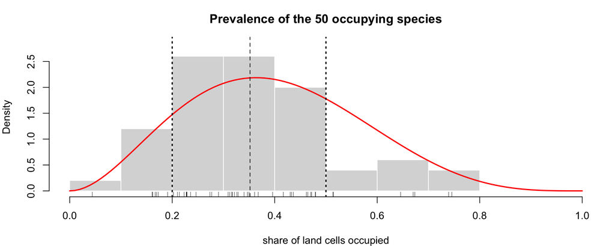

```r
prev     <- apply(world$z, 3, function(m) mean(m[ok]))
prev_occ <- prev[!sp$visitor_only]
a_b      <- cfg$occupancy$prev_shape
h <- hist(prev_occ, breaks = seq(0, 1, by = 0.1), plot = FALSE)
par(mfrow = c(1, 1), mar = c(4, 4, 3, 1))
hist(prev_occ, breaks = seq(0, 1, by = 0.1), freq = FALSE, col = "grey85", border = "white",
     ylim = c(0, max(h$density, dbeta(seq(0.01, 0.99, length.out = 99), a_b[1], a_b[2])) * 1.1),
     xlab = "share of land cells occupied", main = paste("Prevalence of the", length(prev_occ), "occupying species"))
curve(dbeta(x, a_b[1], a_b[2]), add = TRUE, lwd = 2, col = "red")
abline(v = cfg$occupancy$profile_breaks, lty = 3, lwd = 2)
abline(v = mean(prev_occ), lty = 2)
rug(prev_occ)
```

```r
cat("Mean prevalence:", round(mean(prev_occ), 2), "| range:", round(min(prev_occ), 2), "to",
    round(max(prev_occ), 2), "| species above 0.8:", sum(prev_occ > 0.8), "\n")
```

```
## Mean prevalence: 0.35 | range: 0.04 to 0.75 | species above 0.8: 0
```

```r
knitr::kable(table(strategy = sp$strategy, profile = sp$profile),
             caption = "Number of species by strategy and profile")
```

Number of species by strategy and profile

|  | common | intermediate | rare |
| --- | --- | --- | --- |
| long | 3 | 13 | 0 |
| resident | 2 | 11 | 4 |
| short | 2 | 12 | 3 |

### 3.1c. Classification Performance

We assume our classifiers are already calibrated. Classifier scores correspond to correct classification probability.  
For occupied cells: Detections are combination of true detections and false-positives.  
For unoccupied cells: Detections are combination of false positives or true detections from a visiting individual from landscape.  
Classifier Score distributions  
* **true detection** ~ Uniform(0.8, 1)  
* **false positive** ~ Uniform(0.3, 1.0)  
* **visitor true detection** ~ Uniform(0.6, 1.0)

```r
knitr::kable(table(profile = sp$profile, confusable = sp$confusable),
             caption = "Number of species by profile and confusable flag")
```

Number of species by profile and confusable flag

|  | FALSE | TRUE |
| --- | --- | --- |
| common | 6 | 1 |
| intermediate | 29 | 7 |
| rare | 6 | 1 |

### 3.1d. Some species are notaffected by forest fragmentation

Each occupying species is drawn as not affected with probability 0.2 (Bernoulli trial). Unaffected species have all three betas equal to 0 and act as negative controls for the landscape effects.

```r
knitr::kable(table(profile = sp$profile, frag_affected = sp$frag_affected, useNA = "ifany"),
             caption = "Number of species by profile and affected by forest fragmentation")
```

Number of species by profile and affected by forest fragmentation

|  | FALSE | TRUE |
| --- | --- | --- |
| common | 1 | 6 |
| intermediate | 9 | 27 |
| rare | 1 | 6 |

## 3.2. Spatial field e-folding distance

Each occupying species has one e-folding distance (`field_scale_m`, correlation exp(-d / scale), practical range about 3 x scale), drawn independently from the set {NA, 300, 1000, 3000, 10000} in `cfg$occupancy$field_scale_m`; NA means no spatial field.

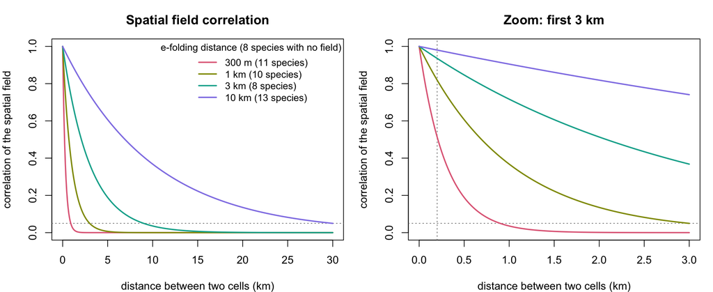

```r
scales <- sort(unique(sp$field_scale_m[!is.na(sp$field_scale_m)]))
if (length(scales) == 0) {
  cat("No species has a spatial field in this world.\n")
} else {
  n_sc   <- sapply(scales, function(s) sum(sp$field_scale_m == s, na.rm = TRUE))
  n_none <- sum(is.na(sp$field_scale_m) & !sp$visitor_only)
  cols   <- hcl.colors(max(length(scales), 3), "Dark 3")[seq_along(scales)]
  labs   <- paste0(ifelse(scales < 1000, paste0(scales, " m"), paste0(scales / 1000, " km")),
                   " (", n_sc, " species)")
  par(mfrow = c(1, 2), mar = c(4, 4, 3, 1))
  for (xmax in c(30, 3)) {
    d_km <- seq(0, xmax, length.out = 400)
    plot(NA, xlim = c(0, xmax), ylim = c(0, 1), xlab = "distance between two cells (km)",
         ylab = "correlation of the spatial field",
         main = if (xmax == 30) "Spatial field correlation" else "Zoom: first 3 km")
    abline(h = 0.05, lty = 3, col = "grey50")
    if (xmax == 3) abline(v = cfg$cell_m / 1000, lty = 3, col = "grey50")
    for (k in seq_along(scales)) lines(d_km, exp(-d_km * 1000 / scales[k]), col = cols[k], lwd = 2)
    if (xmax == 30)
      legend("topright", bty = "n", lwd = 2, col = cols, legend = labs, cex = 0.9,
             title = paste0("e-folding distance (", n_none, " species with no field)"))
  }
}
```

## 3.3. Acoustic sampling scheme

BirdPipes records for 1 minute every 10 minutes for 24 hours, which gives 144 recordings per day. The schedule can be changed with `snippets = list(interval_min = 10, length_min = 1)` in `simv2_00_config.R`.  
Calling rates are flat over the day (no diel pattern yet)  
Two species traits control how often a species is detected in these recordings:

- **`lambda`**: the expected number of true calls per 24 h at full activity, in a cell the species occupies. It is drawn per species (log-uniform) from `profile$<class>$lambda` in the config.
- **`p_visit`**: the daily probability that a species visits a cell it does not occupy (multiplied by the activity curve). While visiting, the species calls at `lambda` x activity x `visit_frac` calls per day (`visit_frac` = 0.021), so a visit is usually caught by only a few recordings, if any. Visitors only occur where `z = 0`.

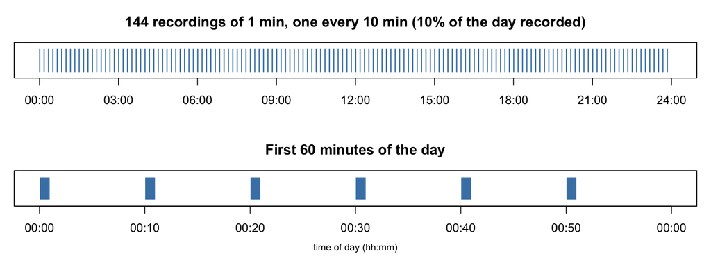

```r
starts <- sim_snippet_starts(cfg)            # start minute of every recording
len    <- cfg$snippets$length_min
S      <- length(starts)
zoom   <- max(60, 3 * cfg$snippets$interval_min)   # minutes shown in the lower panel

par(mfrow = c(2, 1), mar = c(3.5, 1, 3, 1))

# whole day: one tick per recording
plot(NA, xlim = c(0, 24), ylim = c(0, 1), xaxt = "n", yaxt = "n", xlab = "", ylab = "",
     main = paste0(S, " recordings of ", len, " min, one every ", cfg$snippets$interval_min,
                   " min (", round(100 * S * len / 1440, 1), "% of the day recorded)"))
axis(1, at = seq(0, 24, 3), labels = sprintf("%02d:00", seq(0, 24, 3)))
segments((starts + len / 2) / 60, 0.15, (starts + len / 2) / 60, 0.85, col = "steelblue", lwd = 1.5)
box()

# zoom: the actual recordings
plot(NA, xlim = c(0, zoom), ylim = c(0, 1), xaxt = "n", yaxt = "n", xlab = "", ylab = "",
     main = paste0("First ", zoom, " minutes of the day"))
axis(1, at = seq(0, zoom, 10), labels = sprintf("00:%02d", seq(0, zoom, 10) %% 60))
inz <- starts < zoom
rect(starts[inz], 0.15, starts[inz] + len, 0.85, col = "steelblue", border = "white")
mtext("time of day (hh:mm)", side = 1, line = 2.3, cex = 0.8)
box()
```

# 4. Three example species

All species-specific information can be found in “simulated_species.csv”

```r
occ_sp <- sp[!sp$visitor_only, ]

id_forest <- params$species_forest
if (is.null(id_forest)) {
  cand <- occ_sp[occ_sp$profile == "common", ]
  id_forest <- cand$species_id[which.max(cand$beta_forest)]
}
id_edge <- params$species_edge
if (is.null(id_edge)) {
  cand <- occ_sp[!occ_sp$species_id %in% id_forest, ]
  id_edge <- cand$species_id[which.max(cand$beta_edge - cand$beta_forest)]
}
id_conf <- params$species_confusable
if (is.null(id_conf)) {
  cand <- occ_sp[occ_sp$confusable & !occ_sp$species_id %in% c(id_forest, id_edge), ]
  if (nrow(cand) == 0) stop("No confusable species left to pick in this world")
  id_conf <- cand$species_id[which.max(cand$p_fp)]
}
ex_ids <- c(id_forest, id_edge, id_conf)
knitr::kable(sp[match(ex_ids, sp$species_id),
                c("species_id", "strategy", "profile", "confusable", "beta_forest", "beta_edge", "beta_buffer",
                  "lambda", "p_fp", "prevalence_target")],
             digits = 3, caption = "The three example species")
```

The three example species

|  | species_id | strategy | profile | confusable | beta_forest | beta_edge | beta_buffer | lambda | p_fp | prevalence_target |
| --- | --- | --- | --- | --- | --- | --- | --- | --- | --- | --- |
| 16 | sp16 | long | common | FALSE | 0.869 | -0.030 | 0.061 | 38.740 | 0.000 | 0.511 |
| 33 | sp33 | long | intermediate | FALSE | 0.489 | 0.777 | -0.501 | 50.068 | 0.000 | 0.466 |
| 47 | sp47 | long | intermediate | TRUE | 0.000 | 0.000 | 0.000 | 173.574 | 0.002 | 0.310 |

- **Example 1**: the common species with the largest forest effect (a forest species).
- **Example 2**: the species with the most edge-leaning betas (largest `beta_edge - beta_forest`). The betas are random, so check the table: the most edge-leaning species of a world may still have only a weak edge effect.
- **Example 3**: the confusable species with the highest false positive probability (any profile).

Note: Set `species_forest`, `species_edge` or `species_confusable` in the header to look at any other species.

```r
# Draws every figure for one species. Run with results = "asis" (text and tables are printed).
species_report <- function(sp_id, label) {
  s  <- match(sp_id, sp$species_id)
  me <- sp[s, ]
  set.seed(params$cell_seed + s)

  cat("\n\n## ", label, ": ", sp_id, "\n\n", sep = "")

  # ---- properties ----
  cat("### Properties\n\n")
  vals <- sapply(me[1, ], function(v) if (is.numeric(v)) format(signif(v, 3)) else as.character(v))
  print(knitr::kable(data.frame(parameter = names(vals), value = unname(vals))))
  cat("\n\n")

  # ---- beta parameters ----
  cat("### Beta parameters\n\n")
  cat("Top row: the distribution of each beta among the species affected by fragmentation",
      "(dashed = community mean, red = this species; unaffected species have betas of exactly 0).",
      "Bottom row: occupancy probability of this species against each covariate",
      "(other covariates at their mean, no spatial field).\n\n")
  occ_all <- sp[!sp$visitor_only & sp$frag_affected %in% TRUE, ]
  par(mfrow = c(2, 3), mar = c(4, 4, 3, 1))
  for (nm in cfg$cov_names) {
    b <- occ_all[[paste0("beta_", nm)]]
    hist(b, breaks = 12, main = paste("beta", nm), xlab = "effect on logit(psi) per 1 SD",
         col = "grey85", border = "white")
    abline(v = cfg$occupancy$beta_mean[[nm]], lty = 2)
    abline(v = me[[paste0("beta_", nm)]], col = "red", lwd = 2)
  }
  xs <- seq(-2.5, 2.5, length.out = 100)
  for (nm in cfg$cov_names) {
    plot(xs, plogis(me$beta0 + me[[paste0("beta_", nm)]] * xs), type = "l", lwd = 2, ylim = c(0, 1),
         xlab = paste(nm, "(z-score)"), ylab = "occupancy probability", main = nm)
    abline(h = me$prevalence_target, lty = 3, col = "grey50")
  }

  # ---- occupancy maps ----
    cat("\n\n### Occupancy: psi, z and spatial field\n\n")
  cat("Each map has a colour bar. For z, 0 = not occupied and 1 = occupied.\n\n")
  m <- sim_truth_maps(world, sp_id)
  if (!is.null(m$field)) m$field[!ok] <- NA
  layout(matrix(1:6, nrow = 1), widths = c(10, 2.5, 10, 2.5, 10, 2.5))
  pal_psi <- hcl.colors(50, "YlGnBu", rev = TRUE)
  par(mar = c(4, 4, 3, 1))
  sim_image(m$psi, main = "psi (probability of occupancy)", col = pal_psi, zlim = c(0, 1))
  colour_bar(c(0, 1), pal_psi)
  par(mar = c(4, 4, 3, 1))
  sim_image(m$z, main = "z (one random realisation)", col = c("grey90", "darkgreen"), zlim = c(0, 1))
  colour_bar(c(0, 1), rep(c("grey90", "darkgreen"), each = 25), at = c(0.25, 0.75), labels = c("0", "1"))
  par(mar = c(4, 4, 3, 1))
  if (is.null(m$field)) {
    plot.new(); text(0.5, 0.5, "No spatial field\nfor this species")
    plot.new()
  } else {
    zf <- c(-1, 1) * max(abs(m$field), na.rm = TRUE)
    pal_f <- hcl.colors(50, "Blue-Red 3")
    sim_image(m$field, main = "spatial field (logit scale)", col = pal_f, zlim = zf)
    colour_bar(zf, pal_f)
  }
  layout(1)
  cat("\n\nTarget prevalence: ", round(me$prevalence_target, 3),
      " | realised: ", round(mean(m$z, na.rm = TRUE), 3),
      " | field e-folding distance (m): ",
      if (is.na(me$field_scale_m)) "none" else round(me$field_scale_m),
      if (!is.na(me$field_scale_m)) paste0(" | field SD: ", cfg$occupancy$field_sd), "\n\n", sep = "")

  # ---- phenology ----
  cat("### Phenology\n\n")
  cat("Left: this species (red) against all species. Right: the same curve in 25 occupied cells,",
      "each shifted by its own random number of days.\n\n")
  occ <- which(world$z[, , s] == 1, arr.ind = TRUE)
  stopifnot(nrow(occ) > 0)
  par(mfrow = c(1, 2), mar = c(4, 4, 3, 1))
  plot(NA, xlim = range(doys), ylim = c(0, 1), xlab = "day of year", ylab = "activity",
       main = paste(sp_id, "vs all species"))
  for (k in seq_len(nrow(sp))) lines(doys, curves[k, ], col = "grey85")
  lines(doys, curves[s, ], col = "red", lwd = 3)
  points(c(me$onset, me$peak, me$cessation), c(0, 1, 0), pch = 19)
  abline(v = c(cfg$doy_min, cfg$doy_max), lty = 2)
  show <- occ[sample(nrow(occ), min(25, nrow(occ))), , drop = FALSE]
  plot(NA, xlim = range(doys), ylim = c(0, 1), xlab = "day of year", ylab = "activity",
       main = "Cell-to-cell timing (25 occupied cells)")
  for (r in seq_len(nrow(show))) {
    delta <- sim_with_seed(sim_seed(cfg$seed, 13L, show[r, "row"], show[r, "col"]),
                           rnorm(nrow(sp), 0, cfg$pheno$cell_shift_sd))[s]
    lines(doys, sim_activity(doys - delta, me$onset, me$peak, me$cessation, me$shape_kappa),
          col = adjustcolor("red", 0.35))
  }
  abline(v = c(cfg$doy_min, cfg$doy_max), lty = 2)

  # ---- calling features ----
  cat("\n\n### Calling features\n\n")
  S <- sim_n_snippets(cfg)
  f <- S * cfg$snippets$length_min / 1440     # share of the day that is recorded
  cat("lambda = expected true calls in 24 h at full activity (flat through the day); the recorder only",
      "hears the share ", round(f, 3), " of the day (", S, " snippets of ", cfg$snippets$length_min,
      " min). p_fp = false positive probability per snippet;",
      "p_visit = visitor probability per day in a cell the species does not occupy.\n\n", sep = "")
  a <- sim_activity(doys, me$onset, me$peak, me$cessation, me$shape_kappa)
  N <- 1:30
  lo <- cfg$obs$true_score[1]; hi <- cfg$obs$true_score[2]
  par(mfrow = c(1, 3), mar = c(4, 4, 3, 1))
  plot(doys, me$lambda * a, type = "l", lwd = 2, xlab = "day of year",
       ylab = "expected true calls per day", main = "Calls through the season")
  lines(doys, me$lambda * a * f, lwd = 2, lty = 2)
  legend("topright", legend = c("24 h", "in the snippets"), lty = c(1, 2), lwd = 2, bty = "n", cex = 0.8)
  abline(v = c(cfg$doy_min, cfg$doy_max), lty = 2)
  plot(doys, 1 - exp(-me$lambda * a * f), type = "l", lwd = 2, ylim = c(0, 1), xlab = "day of year",
       ylab = "P(at least one true call)", main = "Daily detection chance in snippets, occupied cell")
  abline(v = c(cfg$doy_min, cfg$doy_max), lty = 2)
  plot(N, lo + (hi - lo) * N / (N + 1), type = "b", ylim = c(lo, hi),
       xlab = "true calls in the day", ylab = "expected max score", main = "More calls, higher max score")
  cat("\n\nP(false positive with score >= 0.8) per snippet: ",
      round(me$p_fp * (1 - 0.8) / (1 - 0.3), 6), "; per day: ",
      round(1 - (1 - me$p_fp * (1 - 0.8) / (1 - 0.3))^S, 4), "\n\n", sep = "")

  # ---- a season of daily recordings ----
  cat("### A season of daily recordings at one occupied and one unoccupied cell\n\n")
  cat("The occupied cell is drawn from the species-richest quarter of the cells this species occupies",
      "(set `example_cell` in the header to choose it); the unoccupied cell is random.\n\n")
  cat("Every day of the season is simulated with `sim_truth_day()`, which also gives the source of the",
      "highest score. The sampler only sees the score.\n\n")
  # occupied cell: drawn from the species-richest quarter of the cells this species occupies
  rich_all <- apply(world$z, c(1, 2), sum)                 # true number of species per cell
  r_occ <- rich_all[occ]
  rich_occ <- occ[r_occ >= quantile(r_occ, 0.75), , drop = FALSE]
  oc <- rich_occ[sample(nrow(rich_occ), 1), ]
  if (!is.null(params$example_cell)) {
    rc_ex <- as.numeric(strsplit(params$example_cell, ",")[[1]])
    if (world$z[rc_ex[1], rc_ex[2], s] == 1) {
      oc <- c(row = rc_ex[1], col = rc_ex[2])
    } else {
      cat("Cell ", params$example_cell, " is not occupied by ", sp_id,
          "; using a species-rich occupied cell instead.\n\n", sep = "")
    }
  }
  un_all <- which(world$z[, , s] == 0 & ok, arr.ind = TRUE)
  un <- un_all[sample(nrow(un_all), 1), ]
  series <- function(i, j) {
    do.call(rbind, lapply(cfg$doy_min:cfg$doy_max, function(d) {
      x <- sim_truth_day(i, j, d)[s, ]
      x$doy <- d
      x
    }))
  }
  cols <- c(none = "grey70", true = "darkgreen", visitor = "orange", fp = "red")
  par(mfrow = c(1, 2), mar = c(4, 4, 3, 1))
  for (cell in list(list(oc, "occupied cell"), list(un, "unoccupied cell"))) {
    ts <- series(cell[[1]]["row"], cell[[1]]["col"])
    plot(ts$doy, ts$max_score, pch = 19, col = cols[ts$source], ylim = c(0, 1),
         xlab = "day of year", ylab = "max classifier score (0 = no call)",
         main = paste0(sp_id, ", ", cell[[2]], " (", cell[[1]]["row"], ", ", cell[[1]]["col"], ")"))
    legend("topright", legend = names(cols), col = cols, pch = 19, bty = "n", cex = 0.8)
  }
  invisible(list(sp_id = sp_id, oc = oc, un = un))
}
```

```r
ex1 <- species_report(id_forest, "Example 1, common forest species")
```

## Example 1, common forest species: sp16

### Properties

| parameter | value |
| --- | --- |
| species_id | sp16 |
| strategy | long |
| profile | common |
| confusable | FALSE |
| frag_affected | TRUE |
| visitor_only | FALSE |
| prevalence_target | 0.511 |
| beta0 | 0.0302 |
| beta_forest | 0.869 |
| beta_edge | -0.0297 |
| beta_buffer | 0.061 |
| field_scale_m | 1000 |
| onset | 148 |
| peak | 166 |
| cessation | 201 |
| shape_kappa | 4 |
| lambda | 38.7 |
| p_fp | 0.000259 |
| p_visit | 0.0133 |

### Beta parameters

Top row: the distribution of each beta among the species affected by fragmentation (dashed = community mean, red = this species; unaffected species have betas of exactly 0). Bottom row: occupancy probability of this species against each covariate (other covariates at their mean, no spatial field).

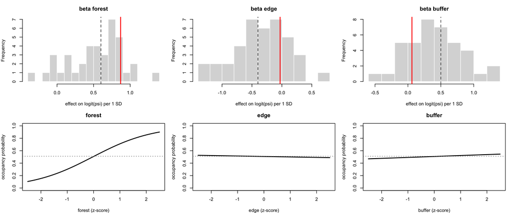

### Occupancy: psi, z and spatial field

Each map has a colour bar. For z, 0 = not occupied and 1 = occupied.

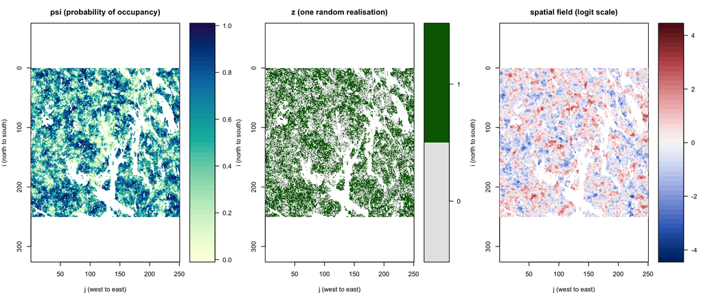

Target prevalence: 0.511 | realised: 0.514 | field e-folding distance (m): 1000 | field SD: 1

### Phenology

Left: this species (red) against all species. Right: the same curve in 25 occupied cells, each shifted by its own random number of days.

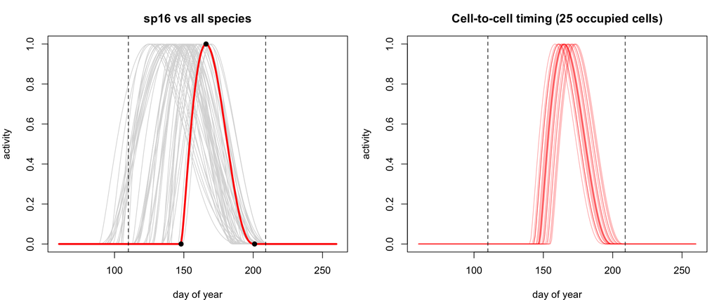

### Calling features

lambda = expected true calls in 24 h at full activity (flat through the day); the recorder onlyhears the share 0.1 of the day (144 snippets of 1 min). p_fp = false positive probability per snippet;p_visit = visitor probability per day in a cell the species does not occupy.

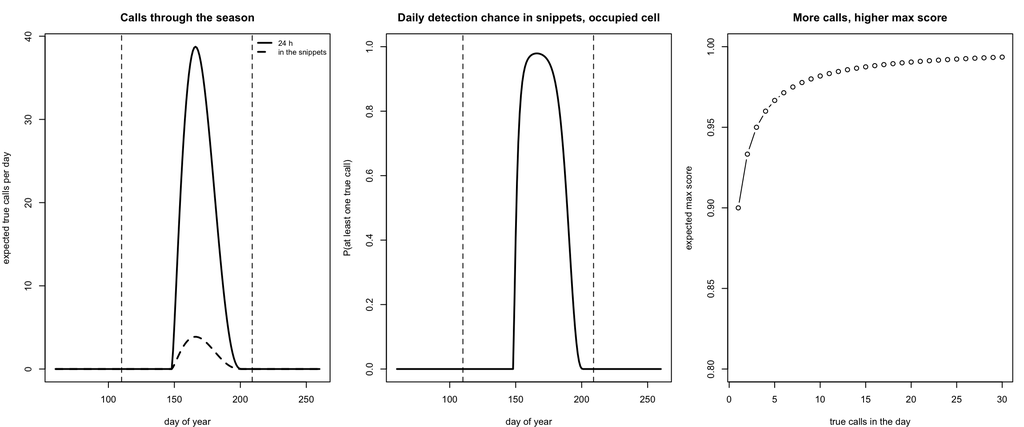

P(false positive with score >= 0.8) per snippet: 7.4e-05; per day: 0.0106

### A season of daily recordings at one occupied and one unoccupied cell

The occupied cell is drawn from the species-richest quarter of the cells this species occupies (set `example_cell` in the header to choose it); the unoccupied cell is random.

Every day of the season is simulated with `sim_truth_day()`, which also gives the source of the highest score. The sampler only sees the score.

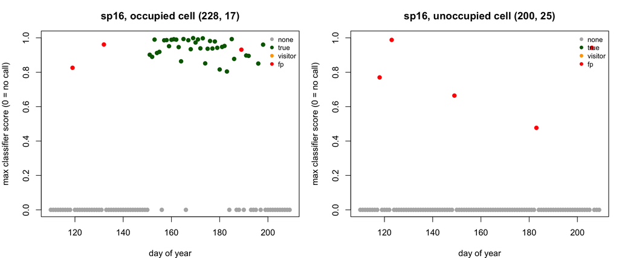

```r
ex2 <- species_report(id_edge, "Example 2, edge species")
```

## Example 2, edge species: sp33

### Properties

| parameter | value |
| --- | --- |
| species_id | sp33 |
| strategy | long |
| profile | intermediate |
| confusable | FALSE |
| frag_affected | TRUE |
| visitor_only | FALSE |
| prevalence_target | 0.466 |
| beta0 | -0.14 |
| beta_forest | 0.489 |
| beta_edge | 0.777 |
| beta_buffer | -0.501 |
| field_scale_m | NA |
| onset | 134 |
| peak | 159 |
| cessation | 214 |
| shape_kappa | 4 |
| lambda | 50.1 |
| p_fp | 0.000143 |
| p_visit | 0.0306 |

### Beta parameters

Top row: the distribution of each beta among the species affected by fragmentation (dashed = community mean, red = this species; unaffected species have betas of exactly 0). Bottom row: occupancy probability of this species against each covariate (other covariates at their mean, no spatial field).

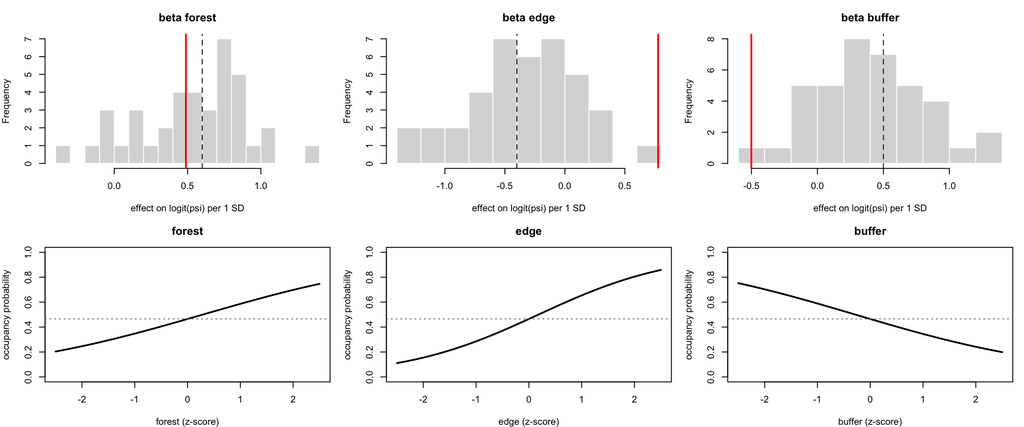

### Occupancy: psi, z and spatial field

Each map has a colour bar. For z, 0 = not occupied and 1 = occupied.

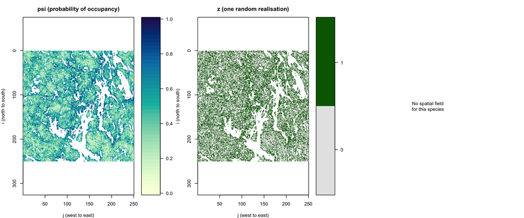

Target prevalence: 0.466 | realised: 0.465 | field e-folding distance (m): none

### Phenology

Left: this species (red) against all species. Right: the same curve in 25 occupied cells, each shifted by its own random number of days.

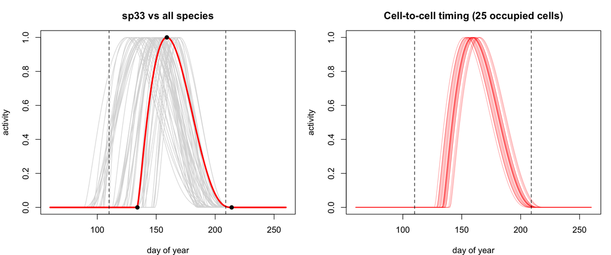

### Calling features

lambda = expected true calls in 24 h at full activity (flat through the day); the recorder onlyhears the share 0.1 of the day (144 snippets of 1 min). p_fp = false positive probability per snippet;p_visit = visitor probability per day in a cell the species does not occupy.

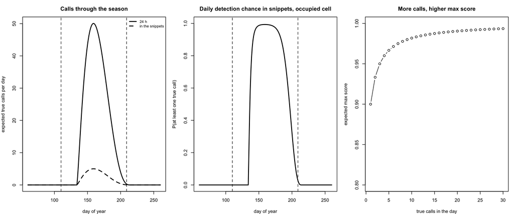

P(false positive with score >= 0.8) per snippet: 4.1e-05; per day: 0.0059

### A season of daily recordings at one occupied and one unoccupied cell

The occupied cell is drawn from the species-richest quarter of the cells this species occupies (set `example_cell` in the header to choose it); the unoccupied cell is random.

Every day of the season is simulated with `sim_truth_day()`, which also gives the source of the highest score. The sampler only sees the score.

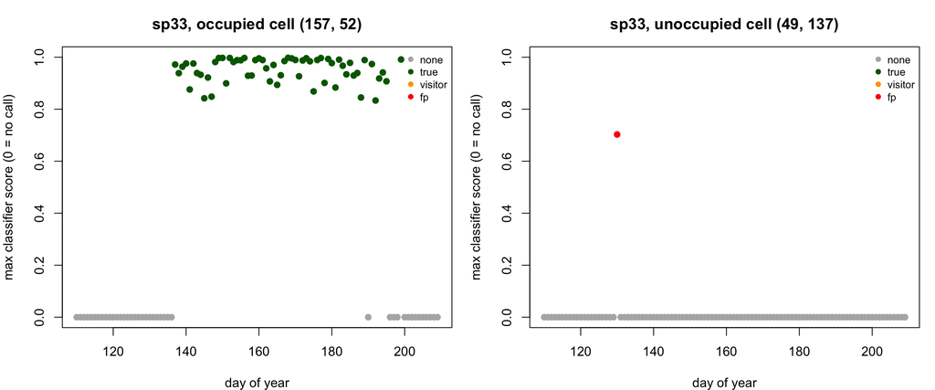

```r
ex3 <- species_report(id_conf, "Example 3, confusable species")
```

## Example 3, confusable species: sp47

### Properties

| parameter | value |
| --- | --- |
| species_id | sp47 |
| strategy | long |
| profile | intermediate |
| confusable | TRUE |
| frag_affected | FALSE |
| visitor_only | FALSE |
| prevalence_target | 0.31 |
| beta0 | -0.976 |
| beta_forest | 0 |
| beta_edge | 0 |
| beta_buffer | 0 |
| field_scale_m | 10000 |
| onset | 135 |
| peak | 155 |
| cessation | 212 |
| shape_kappa | 4 |
| lambda | 174 |
| p_fp | 0.00181 |
| p_visit | 0.05 |

### Beta parameters

Top row: the distribution of each beta among the species affected by fragmentation (dashed = community mean, red = this species; unaffected species have betas of exactly 0). Bottom row: occupancy probability of this species against each covariate (other covariates at their mean, no spatial field).

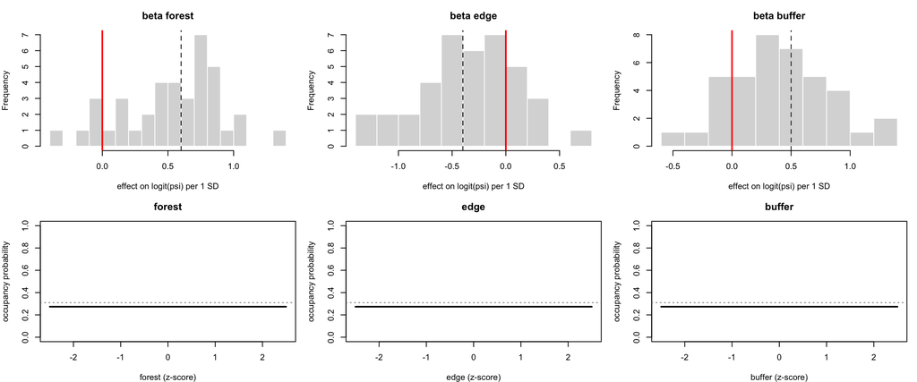

### Occupancy: psi, z and spatial field

Each map has a colour bar. For z, 0 = not occupied and 1 = occupied.

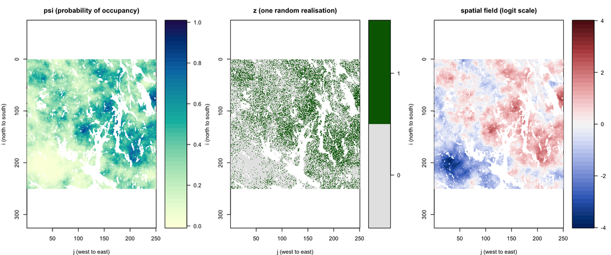

Target prevalence: 0.31 | realised: 0.312 | field e-folding distance (m): 10000 | field SD: 1

### Phenology

Left: this species (red) against all species. Right: the same curve in 25 occupied cells, each shifted by its own random number of days.

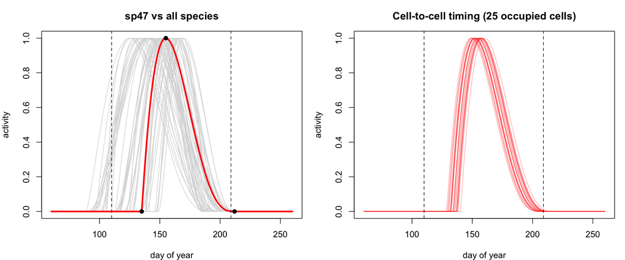

### Calling features

lambda = expected true calls in 24 h at full activity (flat through the day); the recorder onlyhears the share 0.1 of the day (144 snippets of 1 min). p_fp = false positive probability per snippet;p_visit = visitor probability per day in a cell the species does not occupy.

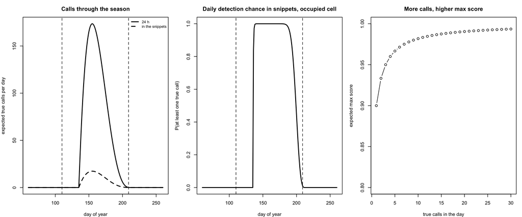

P(false positive with score >= 0.8) per snippet: 0.000516; per day: 0.0717

### A season of daily recordings at one occupied and one unoccupied cell

The occupied cell is drawn from the species-richest quarter of the cells this species occupies (set `example_cell` in the header to choose it); the unoccupied cell is random.

Every day of the season is simulated with `sim_truth_day()`, which also gives the source of the highest score. The sampler only sees the score.

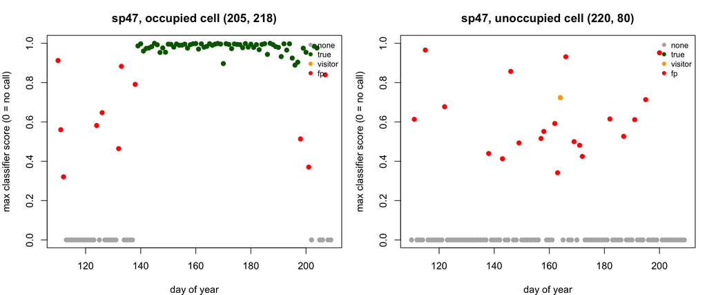

# 5. Demo of the simulator

## One recording

`simulate(i, j, doy)` returns, for one recording day of fixed 1-minute snippets, the highest score per species (`max_score`) and the number of snippets with any detection whatever its score (`n_snip_det`). Here is one recording: the first 10 species and the three examples. By default it is the occupied cell of example 1 on day 140; set `one_cell` and `one_doy` in the header to look at another cell.

```r
if (is.null(params$one_cell)) {
  i1 <- unname(ex1$oc["row"]); j1 <- unname(ex1$oc["col"])
} else {
  rc1 <- as.numeric(strsplit(params$one_cell, ",")[[1]]); i1 <- rc1[1]; j1 <- rc1[2]
}
d1 <- params$one_doy
out <- simulate(i1, j1, d1)
knitr::kable(rbind(head(out, 10), out[out$species_id %in% ex_ids, ]), digits = 3,
             caption = paste0("Recording at cell (", i1, ", ", j1, "), day ", d1))
```

Recording at cell (228, 17), day 140

|  | species_id | max_score | n_snip_det |
| --- | --- | --- | --- |
| 1 | sp01 | 0.000 | 0 |
| 2 | sp02 | 0.963 | 9 |
| 3 | sp03 | 0.997 | 1 |
| 4 | sp04 | 0.912 | 1 |
| 5 | sp05 | 0.997 | 15 |
| 6 | sp06 | 0.000 | 0 |
| 7 | sp07 | 1.000 | 64 |
| 8 | sp08 | 0.000 | 0 |
| 9 | sp09 | 0.000 | 0 |
| 10 | sp10 | 0.960 | 4 |
| 16 | sp16 | 0.000 | 0 |
| 33 | sp33 | 0.000 | 0 |
| 47 | sp47 | 0.000 | 0 |

The same query always returns the same answer:

```r
identical(simulate(i1, j1, d1), out)
```

```
## [1] TRUE
```

## The truth behind the same recording

`sim_truth_day()` shows what produced each score. This is never available to the sampler.

```r
tr <- sim_truth_day(i1, j1, d1)
knitr::kable(tr[tr$species_id %in% ex_ids, ], digits = 3,
             caption = "z = true state, n_true = true calls, source = where the highest score came from")
```

z = true state, n_true = true calls, source = where the highest score came from

|  | species_id | max_score | n_snip_det | n_true | n_true_snips | n_vis_snips | n_fp_snips | visitor | fp | source | z | act |
| --- | --- | --- | --- | --- | --- | --- | --- | --- | --- | --- | --- | --- |
| 16 | sp16 | 0 | 0 | 0 | 0 | 0 | 0 | FALSE | FALSE | none | 1 | 0.000 |
| 33 | sp33 | 0 | 0 | 0 | 0 | 0 | 0 | FALSE | FALSE | none | 0 | 0.000 |
| 47 | sp47 | 0 | 0 | 0 | 0 | 0 | 0 | FALSE | FALSE | none | 0 | 0.347 |

## Several recordings at once

`sim_collect()` takes a table of cells and days. By default there is one cell per day, running from a species-poor to a species-rich cell (by true richness; `cell_seed` picks which cell of each richness); set `demo_cells` and `demo_doy` in the header to choose your own. The first table shows, for each recording, the true number of species in the cell and how many were detected; the second shows every detected species plus the three examples.

```r
demo_days <- as.numeric(strsplit(params$demo_doy, ",")[[1]])
if (is.null(params$demo_cells)) {
  set.seed(params$cell_seed)
  rich <- apply(world$z, c(1, 2), sum)                     # true richness per cell
  nd <- length(demo_days)
  probs <- if (nd > 1) seq(0.1, 0.9, length.out = nd) else 0.5
  target <- round(quantile(rich[ok], probs, type = 1))     # richness of the poor ... rich cells
  pick <- t(sapply(target, function(r) {
    cand <- which(ok & rich == r, arr.ind = TRUE)
    cand[sample(nrow(cand), 1), ]
  }))
  design <- data.frame(i = pick[, 1], j = pick[, 2], doy = demo_days)
} else {
  rc <- do.call(rbind, lapply(strsplit(strsplit(params$demo_cells, ";")[[1]], ","), as.numeric))
  if (nrow(rc) != length(demo_days)) stop("demo_cells and demo_doy need the same number of entries")
  design <- data.frame(i = rc[, 1], j = rc[, 2], doy = demo_days)
}
res <- sim_collect(design)       # stops with a message if a chosen cell is water
rec <- rep(seq_len(nrow(design)), each = nrow(sp))
summary_tab <- data.frame(design,
  true_richness = sapply(seq_len(nrow(design)), function(r) sum(world$z[design$i[r], design$j[r], ])),
  species_detected = as.vector(tapply(res$max_score > 0, rec, sum)))
knitr::kable(summary_tab, caption = "Recordings: true species in the cell and species detected")
```

Recordings: true species in the cell and species detected

|  | i | j | doy | true_richness | species_detected |
| --- | --- | --- | --- | --- | --- |
| 10% | 77 | 75 | 130 | 10 | 7 |
| 50% | 130 | 30 | 150 | 18 | 18 |
| 90% | 210 | 192 | 180 | 25 | 25 |

```r
knitr::kable(res[res$max_score > 0 | res$species_id %in% ex_ids, ], digits = 3,
             caption = "Detected species (max_score > 0) and the three examples")
```

Detected species (max_score > 0) and the three examples

|  | i | j | doy | species_id | max_score | n_snip_det |
| --- | --- | --- | --- | --- | --- | --- |
| 2 | 77 | 75 | 130 | sp02 | 0.852 | 1 |
| 13 | 77 | 75 | 130 | sp13 | 0.996 | 5 |
| 16 | 77 | 75 | 130 | sp16 | 0.000 | 0 |
| 19 | 77 | 75 | 130 | sp19 | 0.995 | 38 |
| 27 | 77 | 75 | 130 | sp27 | 0.992 | 17 |
| 30 | 77 | 75 | 130 | sp30 | 0.871 | 3 |
| 33 | 77 | 75 | 130 | sp33 | 0.000 | 0 |
| 46 | 77 | 75 | 130 | sp46 | 0.971 | 8 |
| 47 | 77 | 75 | 130 | sp47 | 0.964 | 2 |
| 52 | 130 | 30 | 150 | sp02 | 0.447 | 1 |
| 54 | 130 | 30 | 150 | sp04 | 0.989 | 5 |
| 58 | 130 | 30 | 150 | sp08 | 0.941 | 5 |
| 59 | 130 | 30 | 150 | sp09 | 0.999 | 67 |
| 61 | 130 | 30 | 150 | sp11 | 0.999 | 11 |
| 65 | 130 | 30 | 150 | sp15 | 0.941 | 8 |
| 66 | 130 | 30 | 150 | sp16 | 0.000 | 0 |
| 69 | 130 | 30 | 150 | sp19 | 0.994 | 33 |
| 70 | 130 | 30 | 150 | sp20 | 0.998 | 22 |
| 72 | 130 | 30 | 150 | sp22 | 0.978 | 8 |
| 75 | 130 | 30 | 150 | sp25 | 0.897 | 2 |
| 81 | 130 | 30 | 150 | sp31 | 0.994 | 23 |
| 83 | 130 | 30 | 150 | sp33 | 0.000 | 0 |
| 84 | 130 | 30 | 150 | sp34 | 0.978 | 7 |
| 89 | 130 | 30 | 150 | sp39 | 0.989 | 21 |
| 91 | 130 | 30 | 150 | sp41 | 0.959 | 11 |
| 92 | 130 | 30 | 150 | sp42 | 0.996 | 35 |
| 96 | 130 | 30 | 150 | sp46 | 0.827 | 1 |
| 97 | 130 | 30 | 150 | sp47 | 0.000 | 0 |
| 98 | 130 | 30 | 150 | sp48 | 0.998 | 32 |
| 100 | 130 | 30 | 150 | sp50 | 1.000 | 41 |
| 107 | 210 | 192 | 180 | sp07 | 0.862 | 2 |
| 109 | 210 | 192 | 180 | sp09 | 0.996 | 23 |
| 110 | 210 | 192 | 180 | sp10 | 0.960 | 2 |
| 112 | 210 | 192 | 180 | sp12 | 0.966 | 6 |
| 113 | 210 | 192 | 180 | sp13 | 0.933 | 1 |
| 115 | 210 | 192 | 180 | sp15 | 0.956 | 3 |
| 116 | 210 | 192 | 180 | sp16 | 0.818 | 2 |
| 117 | 210 | 192 | 180 | sp17 | 0.980 | 11 |
| 119 | 210 | 192 | 180 | sp19 | 0.999 | 11 |
| 124 | 210 | 192 | 180 | sp24 | 0.867 | 1 |
| 125 | 210 | 192 | 180 | sp25 | 0.991 | 4 |
| 126 | 210 | 192 | 180 | sp26 | 0.988 | 5 |
| 127 | 210 | 192 | 180 | sp27 | 0.600 | 1 |
| 128 | 210 | 192 | 180 | sp28 | 0.998 | 40 |
| 133 | 210 | 192 | 180 | sp33 | 0.000 | 0 |
| 134 | 210 | 192 | 180 | sp34 | 0.953 | 6 |
| 137 | 210 | 192 | 180 | sp37 | 0.994 | 25 |
| 139 | 210 | 192 | 180 | sp39 | 0.992 | 26 |
| 140 | 210 | 192 | 180 | sp40 | 0.996 | 18 |
| 142 | 210 | 192 | 180 | sp42 | 0.989 | 9 |
| 143 | 210 | 192 | 180 | sp43 | 0.856 | 2 |
| 144 | 210 | 192 | 180 | sp44 | 0.988 | 17 |
| 147 | 210 | 192 | 180 | sp47 | 0.959 | 8 |
| 148 | 210 | 192 | 180 | sp48 | 0.996 | 47 |
| 149 | 210 | 192 | 180 | sp49 | 0.970 | 6 |
| 150 | 210 | 192 | 180 | sp50 | 0.971 | 11 |

## 6. True vs HMSC-estimated species-specific beta parameters

We generated simulated data for 100 randomly selected non-water sites and 5 visits per site.  
Fitted HMSC model to this dataset. models_thin_100_samples_250_chains_4  
Blue circles are species whose true beta is non-zero; orange triangles are species whose true beta is 0 (not affected by fragmentation).

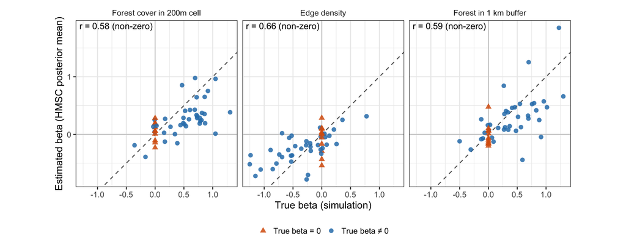

```r
library(readxl)
library(ggplot2)
library(dplyr)
library(tidyr)

true_file <- "../outputs/simulated_species.csv"
est_file  <- "../outputs/hmsc_results/parameter_estimates_Beta_ pa .xlsx"

true_df <- read.csv(true_file, stringsAsFactors = FALSE)
est_df  <- read_excel(est_file)

# pairing of simulated and HMSC column names
pairs <- c(beta_forest = "forest_prop_z",
           beta_edge   = "edge_density_z",
           beta_buffer = "forest_buf1km_z")
panel_labels <- c(beta_forest = "Forest cover in 200m cell",
                  beta_edge   = "Edge density",
                  beta_buffer = "Forest in 1 km buffer")

stopifnot(all(names(pairs) %in% names(true_df)),
          all(pairs %in% names(est_df)))

# Species order: if both tables share a species-name column, match by name;
# otherwise assume the same row order (checked by the row count).
id_true <- intersect(c("species", "species_id", "Species", "sp"), names(true_df))[1]
id_est  <- intersect(c("species", "species_id", "Species", "sp"), names(est_df))[1]

if (!is.na(id_true) && !is.na(id_est)) {
  est_df <- est_df[match(true_df[[id_true]], est_df[[id_est]]), ]
} else {
  stopifnot(nrow(true_df) == nrow(est_df))
  message("No shared species column found; matching by row order.")
}

plot_df <- bind_rows(lapply(names(pairs), function(b) {
  data.frame(covariate = panel_labels[[b]],
             true      = true_df[[b]],
             est       = est_df[[pairs[[b]]]])
})) %>%
  mutate(covariate = factor(covariate, levels = panel_labels),
         effect    = ifelse(true == 0, "True beta = 0", "True beta \u2260 0"))

# correlation of non-zero species, shown in each panel
cors <- plot_df %>%
  filter(true != 0) %>%
  group_by(covariate) %>%
  summarise(r = cor(true, est, use = "complete.obs"), .groups = "drop") %>%
  mutate(label = sprintf("r = %.2f (non-zero)", r))

ggplot(plot_df, aes(true, est, colour = effect, shape = effect)) +
  geom_hline(yintercept = 0, colour = "grey80") +
  geom_vline(xintercept = 0, colour = "grey80") +
  geom_abline(slope = 1, intercept = 0, linetype = "dashed", colour = "grey40") +
  geom_point(size = 3, alpha = 0.85) +
  geom_text(data = cors, aes(label = label), x = -Inf, y = Inf,
            hjust = -0.05, vjust = 1.4, inherit.aes = FALSE, size = 5) +
  scale_colour_manual(values = c("True beta \u2260 0" = "#2c7fb8",
                                 "True beta = 0"     = "#d95f0e"), name = NULL) +
  scale_shape_manual(values = c("True beta \u2260 0" = 16,
                                "True beta = 0"     = 17), name = NULL) +
  facet_wrap(~ covariate, nrow = 1) +
  labs(x = "True beta (simulation)", y = "Estimated beta (HMSC posterior mean)") +
  coord_equal() +
  theme_bw(base_size = 16) +
  theme(legend.position = "bottom", strip.background = element_blank())
```